# Foodhub_Project_Learner_Notebook[Full_Code_Version] (2)

```python
# function to create labeled barplots


def labeled_barplot(data, feature, perc=False, n=None):
    """
    Barplot with percentage at the top

    data: dataframe
    feature: dataframe column
    perc: whether to display percentages instead of count (default is False)
    n: displays the top n category levels (default is None, i.e., display all levels)
    """

    total = len(data[feature])  # length of the column
    count = data[feature].nunique()
    if n is None:
        plt.figure(figsize=(count + 1, 5))
    else:
        plt.figure(figsize=(n + 1, 5))

    plt.xticks(rotation=90, fontsize=15)
    ax = sns.countplot(
        data=data,
        x=feature,
        palette="Paired",
        order=data[feature].value_counts().index[:n].sort_values(),
    )

    for p in ax.patches:
        if perc == True:
            label = "{:.1f}%".format(
                100 * p.get_height() / total
            )  # percentage of each class of the category
        else:
            label = p.get_height()  # count of each level of the category

        x = p.get_x() + p.get_width() / 2  # width of the plot
        y = p.get_height()  # height of the plot

        ax.annotate(
            label,
            (x, y),
            ha="center",
            va="center",
            size=12,
            xytext=(0, 5),
            textcoords="offset points",
        )  # annotate the percentage

    plt.show()  # show the plot
```

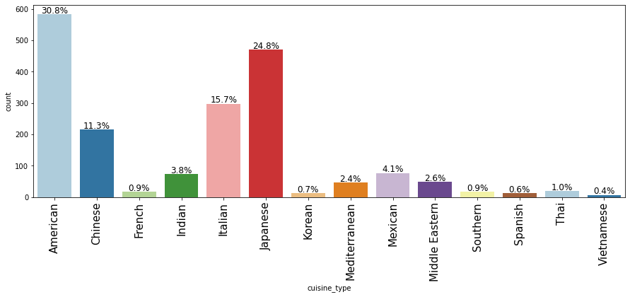

```python
plt.figure(figsize=(10,7))
labeled_barplot(df,'cuisine_type',perc=True)
```

```python
##Observation: American is most ordered ,followed by Japanese
```

```python
df
```

|  | order_id | customer_id | restaurant_name | cuisine_type | cost_of_the_order | day_of_the_week | rating | food_preparation_time | delivery_time |
| --- | --- | --- | --- | --- | --- | --- | --- | --- | --- |
| 0 | 1477147 | 337525 | Hangawi | Korean | 30.75 | Weekend | Not given | 25 | 20 |
| 1 | 1477685 | 358141 | Blue Ribbon Sushi Izakaya | Japanese | 12.08 | Weekend | Not given | 25 | 23 |
| 2 | 1477070 | 66393 | Cafe Habana | Mexican | 12.23 | Weekday | 5 | 23 | 28 |
| 3 | 1477334 | 106968 | Blue Ribbon Fried Chicken | American | 29.20 | Weekend | 3 | 25 | 15 |
| 4 | 1478249 | 76942 | Dirty Bird to Go | American | 11.59 | Weekday | 4 | 25 | 24 |
| ... | ... | ... | ... | ... | ... | ... | ... | ... | ... |
| 1893 | 1476701 | 292602 | Chipotle Mexican Grill $1.99 Delivery | Mexican | 22.31 | Weekend | 5 | 31 | 17 |
| 1894 | 1477421 | 397537 | The Smile | American | 12.18 | Weekend | 5 | 31 | 19 |
| 1895 | 1477819 | 35309 | Blue Ribbon Sushi | Japanese | 25.22 | Weekday | Not given | 31 | 24 |
| 1896 | 1477513 | 64151 | Jack's Wife Freda | Mediterranean | 12.18 | Weekday | 5 | 23 | 31 |
| 1897 | 1478056 | 120353 | Blue Ribbon Sushi | Japanese | 19.45 | Weekend | Not given | 28 | 24 |

1898 rows × 9 columns

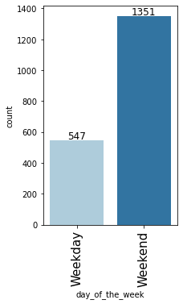

```python
labeled_barplot(df,'day_of_the_week')
```

```python
#Obsevation: weekday having less orders and weekend having more orders.
```

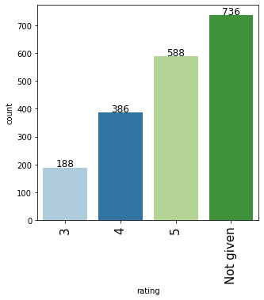

```python
labeled_barplot(df,'rating')
```

```python
#Observation: Rating not given more and rating 5 is of highest
```

### Question 7: Write the code to find the top 5 restaurants that have received the highest number of orders. (1 mark)

```python
# created at data frme using restaurant name and counting
df['restaurant_name'].value_counts().head(5)
```

```
Shake Shack                  219
The Meatball Shop            132
Blue Ribbon Sushi            119
Blue Ribbon Fried Chicken     96
Parm                          68
Name: restaurant_name, dtype: int64
```

#### Observations:

Shake shack is at top 1, and Parm is at 5

### Question 8: Write the code to find the most popular cuisine on weekends. (1 mark)

```python
# filtered for the day_of_the _week in weekens and counted
df1=df.loc[df['day_of_the_week'] == 'Weekend']
df1['cuisine_type'].value_counts()
```

```
American          415
Japanese          335
Italian           207
Chinese           163
Mexican            53
Indian             49
Mediterranean      32
Middle Eastern     32
Thai               15
French             13
Korean             11
Southern           11
Spanish            11
Vietnamese          4
Name: cuisine_type, dtype: int64
```

#### Observations:

The most Popular Cuisine on weekends is American followed by Japaenese.

### Question 9: Write the code to find the number of total orders where the cost is above 20 dollars. What is the percentage of such orders in the dataset? (1 mark)

```python
# created a data frame with cost_of_the_orders >20
df22=df.loc[df['cost_of_the_order']>20]
df22['cost_of_the_order'].value_counts()
df22.shape[0]/df.shape[0]*100
```

```
29.24130663856691
```

#### Observations: There are 29.2% of orders in data set where cost is above 20$

### Question 10: Write the code to find the mean delivery time based on this dataset. (1 mark)

```python
# using mean
df3=df['delivery_time'].mean()
print('The mean delivery time',df3,"mins")
```

```
The mean delivery time 24.161749209694417 mins
```

#### Observations:

The mean delivery time 24.161749209694417 mins

### Question 11: Suppose the company has decided to give a free coupon of 15 dollars to the customer who has spent the maximum amount on a single order. Write the code to find the ID of the customer along with the order details. (1 mark)

```python
#created a data frame with filtered value having max cost -of- the-order

df[df['cost_of_the_order'] == df['cost_of_the_order'].max()]
```

|  | order_id | customer_id | restaurant_name | cuisine_type | cost_of_the_order | day_of_the_week | rating | food_preparation_time | delivery_time |
| --- | --- | --- | --- | --- | --- | --- | --- | --- | --- |
| 573 | 1477814 | 62359 | Pylos | Mediterranean | 35.41 | Weekday | 4 | 21 | 29 |

#### Observations:

The id of customer is 62359 with cost of order is $35.41 and cuisine type is mediterranean